# q4_analysis

Katerina Placek

4/12/2018

# load in cleaned data

With the service_clean data, I first want to see how many times an individual volunteered over the last year.

```r
freq_ID <- as.data.frame(ftable(service_clean$ID))


freq_ID %>%
  summarise(Min=min(Freq, na.rm=TRUE),
            Max=max(Freq, na.rm=TRUE),
            Median=median(Freq, na.rm=TRUE))
```

```
##   Min  Max Median
## 1   1 1082      6
```

There’s an individual with 1082 times Volunteering… possibly a mistake? Let’s see what is different about this individual.

```r
maxIndex <- which.max(freq_ID$Freq)
freq_ID[maxIndex,]
```

```
##     Var1 Freq
## 619 2027 1082
```

```r
service_clean_2027 <- subset(service_clean, service_clean$ID=="2027")
as.data.frame(ftable(service_clean_2027$Assignment))
```

```
##                                                                  Var1 Freq
## 1                                                                      756
## 2        *March 3rd - 11:30-3pm:  Adoption event with Petco Unleashed    1
## 3     *PAWS 11th Annual Mutt Strut - October 14th (Rain Date - 10/15)    2
## 4         April 24th - 11:30-3: Adoption event at Pet Valu Grant Ave.    1
## 5                                             Cat Care Volunteer - GF    2
## 6                                     Cat Care Volunteer - Grant Ave.  310
## 7          December 7th &14th: 11am - 4pm: PetSmart Santa Claws event    2
## 8                                  Dog Walking Volunteer - Grant Ave.    3
## 9       February 13th & 14th - 11am-3pm: Adoption event with PetSmart    1
## 10       July 7th-9th: (various times each day) -  Kittydelphia event    1
## 11 PAWS 11th Annual Mutt Strut - October 14, 2017 (Rain Date - 10/15)    1
## 12   September 10th - 11:30 a.m. - 3 p.m.: Adoption Day with Pet Valu    1
## 13          September 28 - 10:00-3:30: Greensgrow Farms Fall Festival    1
```

It looks like the majority of issues occur when Assignment=“”. Let’s remove individuals with Assignment=“” from the main service_clean dataset and re-check our descriptive statistics.

```r
service_clean <- subset(service_clean, service_clean$Assignment != "")

freq_ID <- as.data.frame(ftable(service_clean$ID))

freq_ID %>%
  summarise(Min=min(Freq, na.rm=TRUE),
            Max=max(Freq, na.rm=TRUE),
            Median=median(Freq, na.rm=TRUE))
```

```
##   Min Max Median
## 1   1 751      6
```

```r
freq_ID  <- dplyr::rename(freq_ID, ID = Var1)
freq_ID  <- dplyr::rename(freq_ID, numTimeVolunteer = Freq)
```

I want to create a new variable for each location that includes the total number of times an individual volunteered at each of the four locations. I save this into a new dataframe.

```r
service_clean$location[is.na(service_clean$location)] = "other"
service_clean$location[service_clean$location==""] = "other"

location <- as.data.frame(ftable(service_clean$ID~service_clean$location))

location <- reshape(location,timevar="service_clean.location",idvar="service_clean.ID",direction="wide")

location <- dplyr::rename(location, ID = service_clean.ID)

location[, 2:6] <- sapply(location[, 2:6], function(x) { as.numeric(x > 0) })
```

Let’s see what location achieves the greatest number of volunteer slots:

```r
data <- as.data.frame(ftable(service_clean$location))

data$per <- data$Freq/sum(data$Freq)

data <- data %>%
  arrange(desc(per))

knitr::kable(data, caption = "Volunteering - More Than Once?")
```

| Var1 | Freq | per |
| --- | --- | --- |
| PAC | 7431 | 0.3359100 |
| Grant Ave. | 6737 | 0.3045385 |
| other | 4279 | 0.1934274 |
| GF | 3087 | 0.1395443 |
| PAWS South Philly PetSmart | 588 | 0.0265799 |

I also want to create a new variable for each assignment that includes the total number of times an individual volunteered for that assignment. I also save this into a new dataframe.

```r
service_clean$assignment_type[service_clean$assignment_type==""] = "other_event"

assignment <- as.data.frame(ftable(service_clean$ID~service_clean$assignment_type))

assignment <- reshape(assignment,timevar="service_clean.assignment_type",idvar="service_clean.ID",direction="wide")


assignment <- dplyr::rename(assignment, ID = service_clean.ID)

assignment[, 2:19] <- sapply(assignment[, 2:19], function(x) { as.numeric(x > 0) })
```

Here, I show a pie chart for frequency of assignment; it looks like Cat Care Volunteer is the most frequent assignment type in our dataset

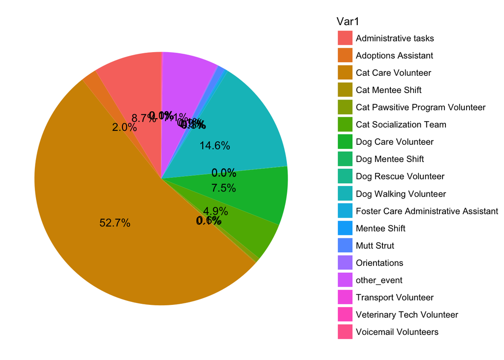

```r
data <- as.data.frame(ftable(service_clean$assignment_type))

data$per <- data$Freq/sum(data$Freq)

data <- data %>%
  arrange(desc(per))

data$label <- scales::percent(data$per)

ggplot(data=data, aes("", per, fill = Var1)) +
  geom_bar(width = 1, size = 1, stat = "identity") +
  coord_polar("y") +
  theme_void()+
  geom_text(aes(label=label), position = position_stack(vjust = 0.5))
```

Now, I merge all datasets together by ID.

```r
service_clean_wide <- service_clean_wide[,1:13]

k_data <- merge(assignment,location, by = "ID")
colnames(k_data) <- gsub("Freq.", "", colnames(k_data))

k_data <- merge(k_data,master_clean, by = "ID")
k_data <- merge(k_data, signup_clean, by = "ID")
k_data <- merge(k_data, service_clean_wide, by = "ID")

k_data <- merge(k_data, freq_ID, by = "ID")
```

B)Time from being entered into the system (and therefore, being able to sign up for shifts) to demonstrating an interest in signing up for shifts (logging into the system for the first time)

3. Time from demonstrating an interest in signing up for shifts (logging into the system for the first time) to shift 1; Remove people whose 1st shift comes before they logged into the system.
4. Time from attending their first orientation to first shift:

Now, can use backward/forward elimination, or LASSO (not sure if necessary, since n>p) to find variables that best predict whether someone is a repeat volunteer or not.

Here, we create a binary dependent variable. How many individuals volunteered only once or were repeat volunteers?

```r
names(k_data)
```

```
##  [1] "ID"
##  [2] "Administrative tasks"
##  [3] "Adoptions Assistant"
##  [4] "Cat Care Volunteer"
##  [5] "Cat Mentee Shift"
##  [6] "Cat Pawsitive Program Volunteer"
##  [7] "Cat Socialization Team"
##  [8] "Dog Care Volunteer"
##  [9] "Dog Mentee Shift"
## [10] "Dog Rescue Volunteer"
## [11] "Dog Walking Volunteer"
## [12] "Foster Care Administrative Assistant"
## [13] "Mentee Shift"
## [14] "Mutt Strut"
## [15] "Orientations"
```

[output cut: 51 more lines]

```r
k_data$numTimeVolunteer2 <- ifelse(k_data$numTimeVolunteer > 1, "repeat", "once")
knitr::kable(table(k_data$numTimeVolunteer2, exclude=NULL), caption = "Volunteering - More Than Once?")
```

Volunteering - More Than Once?

| Var1 | Freq |
| --- | --- |
| once | 81 |
| repeat | 289 |

Next, I subset the dataset to retain variables that likely inform our research question and to remove redundancies in the dataset

```r
keep <- colnames(k_data[2:21])

k_data_reg <- select(k_data, keep, YTD.hours, Absence, city_clean, orient_loc.Primary, orient_type.Primary, t.orientation.to.entered, t.entered.to.start, t.start.to.shift1, t.orientation.to.shift1, numTimeVolunteer, numTimeVolunteer2)

summary(k_data_reg)
```

```
##  Administrative tasks Adoptions Assistant Cat Care Volunteer
##  Min.   :0.00000      Min.   :0.00000     Min.   :0.0000
##  1st Qu.:0.00000      1st Qu.:0.00000     1st Qu.:0.0000
##  Median :0.00000      Median :0.00000     Median :1.0000
##  Mean   :0.04054      Mean   :0.01351     Mean   :0.6811
##  3rd Qu.:0.00000      3rd Qu.:0.00000     3rd Qu.:1.0000
##  Max.   :1.00000      Max.   :1.00000     Max.   :1.0000
##  Cat Mentee Shift  Cat Pawsitive Program Volunteer Cat Socialization Team
##  Min.   :0.00000   Min.   :0.00000                 Min.   :0.000000
##  1st Qu.:0.00000   1st Qu.:0.00000                 1st Qu.:0.000000
##  Median :0.00000   Median :0.00000                 Median :0.000000
##  Mean   :0.04324   Mean   :0.02432                 Mean   :0.008108
##  3rd Qu.:0.00000   3rd Qu.:0.00000                 3rd Qu.:0.000000
##  Max.   :1.00000   Max.   :1.00000                 Max.   :1.000000
##  Dog Care Volunteer Dog Mentee Shift  Dog Rescue Volunteer
##  Min.   :0.0000     Min.   :0.00000   Min.   :0
##  1st Qu.:0.0000     1st Qu.:0.00000   1st Qu.:0
##  Median :0.0000     Median :0.00000   Median :0
##  Mean   :0.2243     Mean   :0.01081   Mean   :0
##  3rd Qu.:0.0000     3rd Qu.:0.00000   3rd Qu.:0
##  Max.   :1.0000     Max.   :1.00000   Max.   :0
##  Dog Walking Volunteer Foster Care Administrative Assistant
##  Min.   :0.0000        Min.   :0
##  1st Qu.:0.0000        1st Qu.:0
##  Median :0.0000        Median :0
##  Mean   :0.2081        Mean   :0
##  3rd Qu.:0.0000        3rd Qu.:0
##  Max.   :1.0000        Max.   :0
##   Mentee Shift       Mutt Strut       Orientations  other_event
##  Min.   :0.00000   Min.   :0.00000   Min.   :0     Min.   :0.0000
##  1st Qu.:0.00000   1st Qu.:0.00000   1st Qu.:0     1st Qu.:0.0000
##  Median :0.00000   Median :0.00000   Median :0     Median :0.0000
##  Mean   :0.02432   Mean   :0.03514   Mean   :0     Mean   :0.1459
##  3rd Qu.:0.00000   3rd Qu.:0.00000   3rd Qu.:0     3rd Qu.:0.0000
##  Max.   :1.00000   Max.   :1.00000   Max.   :0     Max.   :1.0000
##  Transport Volunteer Veterinary Tech Volunteer Voicemail Volunteers
##  Min.   :0           Min.   :0.00000           Min.   :0
##  1st Qu.:0           1st Qu.:0.00000           1st Qu.:0
##  Median :0           Median :0.00000           Median :0
##  Mean   :0           Mean   :0.01351           Mean   :0
```

[output cut: 15 more lines]

```
##
##  t.orientation.to.entered t.entered.to.start t.start.to.shift1
##  Length:370               Length:370         Length:370
##  Class :difftime          Class :difftime    Class :difftime
##  Mode  :numeric           Mode  :numeric     Mode  :numeric
##
##
##
##  t.orientation.to.shift1 numTimeVolunteer  numTimeVolunteer2
##  Length:370              Min.   :  1.000   Length:370
##  Class :difftime         1st Qu.:  2.000   Class :character
##  Mode  :numeric          Median :  4.000   Mode  :character
##                          Mean   :  9.459
##                          3rd Qu.: 11.000
##                          Max.   :124.000
```

Next, lets look at a heatmap of correlation between variables with numeric values in our reduced dataset:

```r
k_data_heatmap <- select_if(k_data_reg, is.numeric)

summary(k_data_heatmap)
```

```
##  Administrative tasks Adoptions Assistant Cat Care Volunteer
##  Min.   :0.00000      Min.   :0.00000     Min.   :0.0000
##  1st Qu.:0.00000      1st Qu.:0.00000     1st Qu.:0.0000
##  Median :0.00000      Median :0.00000     Median :1.0000
##  Mean   :0.04054      Mean   :0.01351     Mean   :0.6811
##  3rd Qu.:0.00000      3rd Qu.:0.00000     3rd Qu.:1.0000
##  Max.   :1.00000      Max.   :1.00000     Max.   :1.0000
##  Cat Mentee Shift  Cat Pawsitive Program Volunteer Cat Socialization Team
##  Min.   :0.00000   Min.   :0.00000                 Min.   :0.000000
##  1st Qu.:0.00000   1st Qu.:0.00000                 1st Qu.:0.000000
##  Median :0.00000   Median :0.00000                 Median :0.000000
##  Mean   :0.04324   Mean   :0.02432                 Mean   :0.008108
##  3rd Qu.:0.00000   3rd Qu.:0.00000                 3rd Qu.:0.000000
##  Max.   :1.00000   Max.   :1.00000                 Max.   :1.000000
##  Dog Care Volunteer Dog Mentee Shift  Dog Rescue Volunteer
##  Min.   :0.0000     Min.   :0.00000   Min.   :0
##  1st Qu.:0.0000     1st Qu.:0.00000   1st Qu.:0
##  Median :0.0000     Median :0.00000   Median :0
##  Mean   :0.2243     Mean   :0.01081   Mean   :0
##  3rd Qu.:0.0000     3rd Qu.:0.00000   3rd Qu.:0
##  Max.   :1.0000     Max.   :1.00000   Max.   :0
##  Dog Walking Volunteer Foster Care Administrative Assistant
##  Min.   :0.0000        Min.   :0
##  1st Qu.:0.0000        1st Qu.:0
##  Median :0.0000        Median :0
##  Mean   :0.2081        Mean   :0
##  3rd Qu.:0.0000        3rd Qu.:0
##  Max.   :1.0000        Max.   :0
##   Mentee Shift       Mutt Strut       Orientations  other_event
##  Min.   :0.00000   Min.   :0.00000   Min.   :0     Min.   :0.0000
##  1st Qu.:0.00000   1st Qu.:0.00000   1st Qu.:0     1st Qu.:0.0000
##  Median :0.00000   Median :0.00000   Median :0     Median :0.0000
##  Mean   :0.02432   Mean   :0.03514   Mean   :0     Mean   :0.1459
##  3rd Qu.:0.00000   3rd Qu.:0.00000   3rd Qu.:0     3rd Qu.:0.0000
##  Max.   :1.00000   Max.   :1.00000   Max.   :0     Max.   :1.0000
##  Transport Volunteer Veterinary Tech Volunteer Voicemail Volunteers
##  Min.   :0           Min.   :0.00000           Min.   :0
##  1st Qu.:0           1st Qu.:0.00000           1st Qu.:0
##  Median :0           Median :0.00000           Median :0
##  Mean   :0           Mean   :0.01351           Mean   :0
##  3rd Qu.:0           3rd Qu.:0.00000           3rd Qu.:0
##  Max.   :0           Max.   :1.00000           Max.   :0
##        GF           Grant Ave.       YTD.hours         Absence
##  Min.   :0.0000   Min.   :0.0000   Min.   : 0.000   Min.   :0.00000
##  1st Qu.:0.0000   1st Qu.:0.0000   1st Qu.: 0.000   1st Qu.:0.00000
##  Median :0.0000   Median :0.0000   Median : 2.000   Median :0.00000
##  Mean   :0.2919   Mean   :0.2027   Mean   : 5.242   Mean   :0.03243
##  3rd Qu.:1.0000   3rd Qu.:0.0000   3rd Qu.: 5.938   3rd Qu.:0.00000
##  Max.   :1.0000   Max.   :1.0000   Max.   :94.500   Max.   :2.00000
##  numTimeVolunteer
##  Min.   :  1.000
##  1st Qu.:  2.000
##  Median :  4.000
##  Mean   :  9.459
##  3rd Qu.: 11.000
##  Max.   :124.000
```

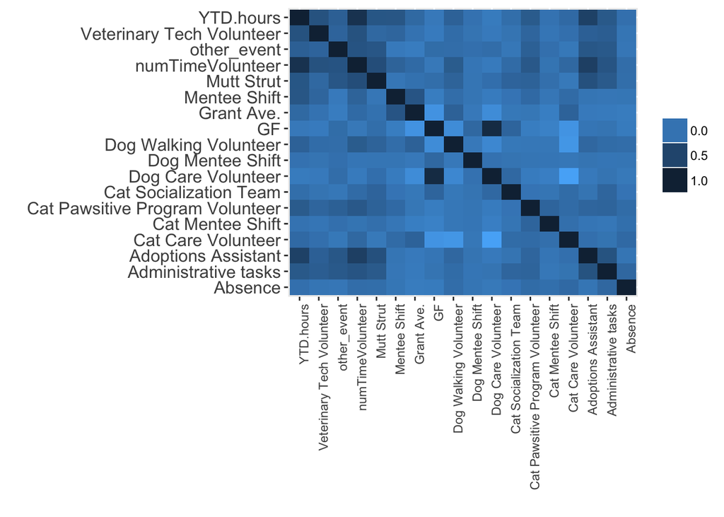

```r
#remove variables with only values of 0 for prettier heatmap
k_data_heatmap <- select(k_data_heatmap, -`Dog Rescue Volunteer`, -`Foster Care Administrative Assistant`, -Orientations, -`Transport Volunteer`, -`Voicemail Volunteers`)

#lets also remove these variables from the main dataset
k_data_reg <- select(k_data_reg, -`Dog Rescue Volunteer`, -`Foster Care Administrative Assistant`, -Orientations, -`Transport Volunteer`, -`Voicemail Volunteers`)

plotData <-melt(cor(k_data_heatmap[sapply(k_data_heatmap, is.numeric)]))

plotData <- plotData[complete.cases(plotData[,"value"]),]

ggplot(plotData ,
    aes(x = X1, y = X2, fill =value)) +
    geom_tile() +
    ylab("") +
    xlab("") +
    theme(legend.title = element_blank(),
           axis.text.x = element_text(angle=90,hjust=1,vjust=1.0),
           axis.text.y = element_text(size = 12))+
scale_x_discrete(limits = rev(levels(plotData$X2))) + #Flip the x- or y-axis
    scale_fill_gradient( low = "#56B1F7", high = "#132B43") +
       guides(fill = guide_legend(title = "Correlation"))
```

Now to test some hypotheses: Do individuals from Philadelphia tend to volunteer more?

```r
(cityMod <- lm(numTimeVolunteer~city_clean, data = k_data_reg))
```

```
##
## Call:
## lm(formula = numTimeVolunteer ~ city_clean, data = k_data_reg)
##
## Coefficients:
##            (Intercept)  city_cleanPhiladelphia
##                 10.378                  -1.149
```

```r
summary(cityMod)
```

```
##
## Call:
## lm(formula = numTimeVolunteer ~ city_clean, data = k_data_reg)
##
## Residuals:
##     Min      1Q  Median      3Q     Max
##  -9.378  -7.378  -5.230   0.770 114.770
##
## Coefficients:
##                        Estimate Std. Error t value Pr(>|t|)
## (Intercept)              10.378      1.797   5.776 1.63e-08 ***
## city_cleanPhiladelphia   -1.149      2.009  -0.572    0.568
## ---
## Signif. codes:  0 '***' 0.001 '**' 0.01 '*' 0.05 '.' 0.1 ' ' 1
##
## Residual standard error: 15.46 on 368 degrees of freedom
## Multiple R-squared:  0.0008875,  Adjusted R-squared:  -0.001827
## F-statistic: 0.3269 on 1 and 368 DF,  p-value: 0.5678
```

Whether someone is from Philadelphia or not doesn’t seem to affect the number of times a person volunteers.

Does length of time between orientation and shift1 affect the number of times a person volunteers?

```r
(timeToVolunteerMod <- lm(numTimeVolunteer~ t.orientation.to.shift1, data = k_data_reg))
```

```
##
## Call:
## lm(formula = numTimeVolunteer ~ t.orientation.to.shift1, data = k_data_reg)
##
## Coefficients:
##             (Intercept)  t.orientation.to.shift1
##                10.57570                 -0.02514
```

```r
summary(timeToVolunteerMod)
```

```
##
## Call:
## lm(formula = numTimeVolunteer ~ t.orientation.to.shift1, data = k_data_reg)
##
## Residuals:
##     Min      1Q  Median      3Q     Max
##  -9.500  -7.807  -5.111   1.003 113.651
##
## Coefficients:
##                         Estimate Std. Error t value Pr(>|t|)
## (Intercept)             10.57570    0.93509  11.310   <2e-16 ***
## t.orientation.to.shift1 -0.02514    0.01097  -2.292   0.0225 *
## ---
## Signif. codes:  0 '***' 0.001 '**' 0.01 '*' 0.05 '.' 0.1 ' ' 1
##
## Residual standard error: 15.36 on 368 degrees of freedom
## Multiple R-squared:  0.01408,    Adjusted R-squared:  0.0114
## F-statistic: 5.254 on 1 and 368 DF,  p-value: 0.02246
```

The greater the time between orientation and shift 1, the less number of times a volunteer showed up.

Next, lets try feature selection using forward/backward selection.

```r
names(k_data_reg)
```

```
##  [1] "Administrative tasks"            "Adoptions Assistant"
##  [3] "Cat Care Volunteer"              "Cat Mentee Shift"
##  [5] "Cat Pawsitive Program Volunteer" "Cat Socialization Team"
##  [7] "Dog Care Volunteer"              "Dog Mentee Shift"
##  [9] "Dog Walking Volunteer"           "Mentee Shift"
## [11] "Mutt Strut"                      "other_event"
## [13] "Veterinary Tech Volunteer"       "GF"
## [15] "Grant Ave."                      "YTD.hours"
## [17] "Absence"                         "city_clean"
## [19] "orient_loc.Primary"              "orient_type.Primary"
## [21] "t.orientation.to.entered"        "t.entered.to.start"
## [23] "t.start.to.shift1"               "t.orientation.to.shift1"
## [25] "numTimeVolunteer"                "numTimeVolunteer2"
```

```r
k_data_reg <- select(k_data_reg, -numTimeVolunteer2)

(fit.forward <- regsubsets(numTimeVolunteer ~., k_data_reg, nvmax=60, method="forward"))
```

```
## Reordering variables and trying again:
```

```
## Subset selection object
## Call: regsubsets.formula(numTimeVolunteer ~ ., k_data_reg, nvmax = 60,
##     method = "forward")
## 28 Variables  (and intercept)
##                                   Forced in Forced out
## `Administrative tasks`                FALSE      FALSE
## `Adoptions Assistant`                 FALSE      FALSE
## `Cat Care Volunteer`                  FALSE      FALSE
## `Cat Mentee Shift`                    FALSE      FALSE
## `Cat Pawsitive Program Volunteer`     FALSE      FALSE
## `Cat Socialization Team`              FALSE      FALSE
## `Dog Care Volunteer`                  FALSE      FALSE
## `Dog Mentee Shift`                    FALSE      FALSE
## `Dog Walking Volunteer`               FALSE      FALSE
## `Mentee Shift`                        FALSE      FALSE
## `Mutt Strut`                          FALSE      FALSE
## other_event                           FALSE      FALSE
## `Veterinary Tech Volunteer`           FALSE      FALSE
## GF                                    FALSE      FALSE
## `Grant Ave.`                          FALSE      FALSE
## YTD.hours                             FALSE      FALSE
## Absence                               FALSE      FALSE
## city_cleanPhiladelphia                FALSE      FALSE
## orient_loc.PrimaryNE                  FALSE      FALSE
## orient_loc.PrimaryPAC                 FALSE      FALSE
## orient_type.PrimaryBasic + WD         FALSE      FALSE
## orient_type.PrimaryCat                FALSE      FALSE
## orient_type.PrimaryWD                 FALSE      FALSE
## t.orientation.to.entered              FALSE      FALSE
## t.entered.to.start                    FALSE      FALSE
## t.start.to.shift1                     FALSE      FALSE
## orient_type.PrimaryDog                FALSE      FALSE
## t.orientation.to.shift1               FALSE      FALSE
## 1 subsets of each size up to 26
## Selection Algorithm: forward
```

Next, lets try feature selection using backward selection.

```r
(fit.backward <- regsubsets(numTimeVolunteer ~., k_data_reg, nvmax=60, method="backward", really.big = TRUE))
```

```
## Reordering variables and trying again:
```

```
## Subset selection object
## Call: regsubsets.formula(numTimeVolunteer ~ ., k_data_reg, nvmax = 60,
##     method = "backward", really.big = TRUE)
## 28 Variables  (and intercept)
##                                   Forced in Forced out
## `Administrative tasks`                FALSE      FALSE
## `Adoptions Assistant`                 FALSE      FALSE
## `Cat Care Volunteer`                  FALSE      FALSE
## `Cat Mentee Shift`                    FALSE      FALSE
## `Cat Pawsitive Program Volunteer`     FALSE      FALSE
## `Cat Socialization Team`              FALSE      FALSE
## `Dog Care Volunteer`                  FALSE      FALSE
## `Dog Mentee Shift`                    FALSE      FALSE
## `Dog Walking Volunteer`               FALSE      FALSE
## `Mentee Shift`                        FALSE      FALSE
## `Mutt Strut`                          FALSE      FALSE
## other_event                           FALSE      FALSE
## `Veterinary Tech Volunteer`           FALSE      FALSE
## GF                                    FALSE      FALSE
## `Grant Ave.`                          FALSE      FALSE
## YTD.hours                             FALSE      FALSE
## Absence                               FALSE      FALSE
## city_cleanPhiladelphia                FALSE      FALSE
## orient_loc.PrimaryNE                  FALSE      FALSE
## orient_loc.PrimaryPAC                 FALSE      FALSE
## orient_type.PrimaryBasic + WD         FALSE      FALSE
## orient_type.PrimaryCat                FALSE      FALSE
## orient_type.PrimaryWD                 FALSE      FALSE
## t.orientation.to.entered              FALSE      FALSE
## t.entered.to.start                    FALSE      FALSE
## t.start.to.shift1                     FALSE      FALSE
## orient_type.PrimaryDog                FALSE      FALSE
## t.orientation.to.shift1               FALSE      FALSE
## 1 subsets of each size up to 26
## Selection Algorithm: backward
```

Too many linear dependencies in the dataset to use forward or backward selection. Time to try LASSO?

```r
k_data_reg <-k_data_reg[complete.cases(k_data_reg),]
#set dependent variable
Y <- k_data_reg$numTimeVolunteer

#set independent variable matrix
X <- model.matrix(numTimeVolunteer~., data = k_data_reg)
colnames(X)
```

```
##  [1] "(Intercept)"
##  [2] "`Administrative tasks`"
##  [3] "`Adoptions Assistant`"
##  [4] "`Cat Care Volunteer`"
##  [5] "`Cat Mentee Shift`"
##  [6] "`Cat Pawsitive Program Volunteer`"
##  [7] "`Cat Socialization Team`"
##  [8] "`Dog Care Volunteer`"
##  [9] "`Dog Mentee Shift`"
## [10] "`Dog Walking Volunteer`"
## [11] "`Mentee Shift`"
## [12] "`Mutt Strut`"
## [13] "other_event"
## [14] "`Veterinary Tech Volunteer`"
## [15] "GF"
## [16] "`Grant Ave.`"
## [17] "YTD.hours"
## [18] "Absence"
## [19] "city_cleanPhiladelphia"
## [20] "orient_loc.PrimaryNE"
## [21] "orient_loc.PrimaryPAC"
## [22] "orient_type.PrimaryBasic + WD"
## [23] "orient_type.PrimaryCat"
## [24] "orient_type.PrimaryDog"
## [25] "orient_type.PrimaryWD"
## [26] "t.orientation.to.entered"
## [27] "t.entered.to.start"
## [28] "t.start.to.shift1"
## [29] "t.orientation.to.shift1"
```

Let’s first see what our lambda options are:

```r
fit.lambda <- glmnet(X, Y, alpha=1)
str(fit.lambda)
```

```
## List of 12
##  $ a0       : Named num [1:75] 9.51 9.03 8.6 8.2 7.84 ...
##   ..- attr(*, "names")= chr [1:75] "s0" "s1" "s2" "s3" ...
##  $ beta     :Formal class 'dgCMatrix' [package "Matrix"] with 6 slots
##   .. ..@ i       : int [1:1059] 16 16 16 16 16 16 16 2 16 2 ...
##   .. ..@ p       : int [1:76] 0 0 1 2 3 4 5 6 7 9 ...
##   .. ..@ Dim     : int [1:2] 29 75
##   .. ..@ Dimnames:List of 2
##   .. .. ..$ : chr [1:29] "(Intercept)" "`Administrative tasks`" "`Adoptions Assistant`" "`Cat Care Volunteer`" ...
##   .. .. ..$ : chr [1:75] "s0" "s1" "s2" "s3" ...
##   .. ..@ x       : num [1:1059] 0.0902 0.1724 0.2472 0.3154 0.3776 ...
##   .. ..@ factors : list()
##  $ df       : int [1:75] 0 1 1 1 1 1 1 1 2 2 ...
##  $ dim      : int [1:2] 29 75
##  $ lambda   : num [1:75] 11.26 10.26 9.35 8.52 7.76 ...
##  $ dev.ratio: num [1:75] 0 0.0902 0.165 0.2272 0.2788 ...
##  $ nulldev  : num 87864
##  $ npasses  : int 473
##  $ jerr     : int 0
##  $ offset   : logi FALSE
##  $ call     : language glmnet(x = X, y = Y, alpha = 1)
##  $ nobs     : int 368
##  - attr(*, "class")= chr [1:2] "elnet" "glmnet"
```

```r
fit.lambda$lambda # see the default proposal of lambda's
```

```
##  [1] 11.26080092 10.26042241  9.34891476  8.51838294  7.76163328
##  [6]  7.07211117  6.44384430  5.87139093  5.34979275  4.87453190
## [11]  4.44149192  4.04692202  3.68740462  3.35982576  3.06134810
## [16]  2.78938637  2.54158497  2.31579757  2.11006850  1.92261583
## [21]  1.75181594  1.59618944  1.45438837  1.32518451  1.20745877
## [26]  1.10019146  1.00245349  0.91339828  0.83225450  0.75831930
## [31]  0.69095230  0.62957000  0.57364074  0.52268008  0.47624662
## [36]  0.43393818  0.39538831  0.36026310  0.32825832  0.29909676
## [41]  0.27252583  0.24831538  0.22625573  0.20615579  0.18784148
## [46]  0.17115416  0.15594930  0.14209519  0.12947185  0.11796992
## [51]  0.10748980  0.09794070  0.08923992  0.08131209  0.07408855
## [56]  0.06750673  0.06150962  0.05604527  0.05106636  0.04652977
## [61]  0.04239619  0.03862983  0.03519806  0.03207116  0.02922205
## [66]  0.02662604  0.02426066  0.02210541  0.02014163  0.01835230
## [71]  0.01672193  0.01523640  0.01388284  0.01264953  0.01152578
```

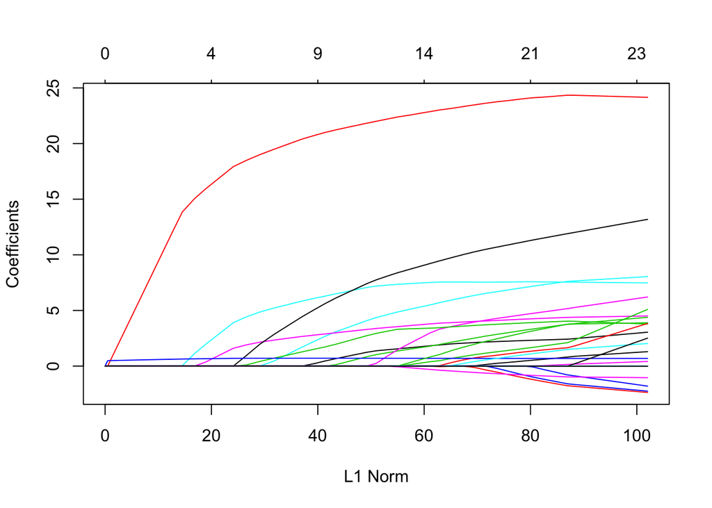

```r
plot(fit.lambda)
```

As L1Norm decreases in value, our lambda value is larger meaning a sparser solution for our analysis. Let’s employ cross-validation to select an appropriate lamdba.

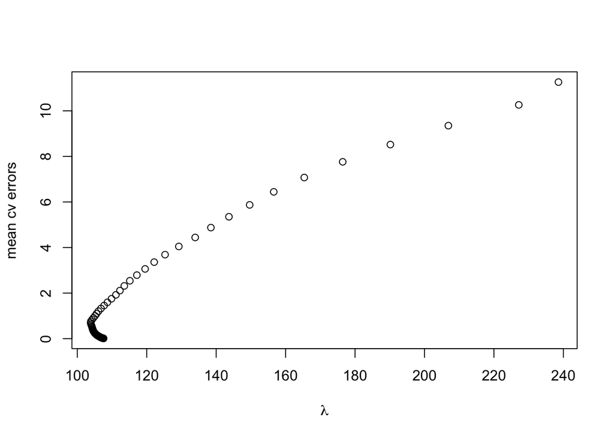

```r
fit.cv <- cv.glmnet(X, Y, alpha=1, nfolds=10 )
plot(fit.cv$cvm, fit.cv$lambda, xlab=expression(lambda), ylab="mean cv errors")
```

```r
fit.cv$cvm               # the mean cv error for each lambda
```

```
##  [1] 238.5799 227.1596 206.8719 190.1742 176.4440 165.3663 156.5817
##  [8] 149.6458 143.6755 138.4791 133.9536 129.2427 125.2759 122.1445
## [15] 119.5281 117.1541 115.1370 113.5282 112.2724 111.1099 109.8524
## [22] 108.6762 107.7130 106.8225 106.1022 105.5541 105.1025 104.6413
## [29] 104.2262 103.8954 103.8411 103.9427 104.0987 104.2131 104.3030
## [36] 104.3849 104.4669 104.5529 104.6617 104.7740 104.8876 105.0207
## [43] 105.1661 105.2959 105.4115 105.5263 105.6468 105.7758 105.9124
## [50] 106.0466 106.1670 106.2686 106.3636 106.4512 106.5250 106.5938
## [57] 106.6714 106.7469 106.8194 106.8917 106.9616 107.0288 107.0877
## [64] 107.1449 107.1994 107.2505 107.2993 107.3463 107.3905 107.4324
## [71] 107.4714 107.5105 107.5465 107.5813
```

```r
#plot(fit.fl.cv$lambda, fit.fl.cv$cvm, xlab="lambda", ylab="mean cv errors")
fit.cv$lambda.min        # lambda.min returns the min point amoth all the cvm.
```

```
## [1] 0.6909523
```

```r
fit.cv$nzero             # number of non-zero coeff's returned for each lambda
```

```
##  s0  s1  s2  s3  s4  s5  s6  s7  s8  s9 s10 s11 s12 s13 s14 s15 s16 s17
##   0   1   1   1   1   1   1   1   2   2   2   2   2   3   3   4   4   4
## s18 s19 s20 s21 s22 s23 s24 s25 s26 s27 s28 s29 s30 s31 s32 s33 s34 s35
##   4   7   7   8   8   8   9   9  10  10  10  10  11  11  13  14  14  14
## s36 s37 s38 s39 s40 s41 s42 s43 s44 s45 s46 s47 s48 s49 s50 s51 s52 s53
##  16  16  16  18  18  19  19  19  19  21  22  22  22  22  23  23  23  23
## s54 s55 s56 s57 s58 s59 s60 s61 s62 s63 s64 s65 s66 s67 s68 s69 s70 s71
##  23  23  23  23  23  23  23  23  23  23  23  23  23  23  23  23  23  23
## s72 s73
##  24  24
```

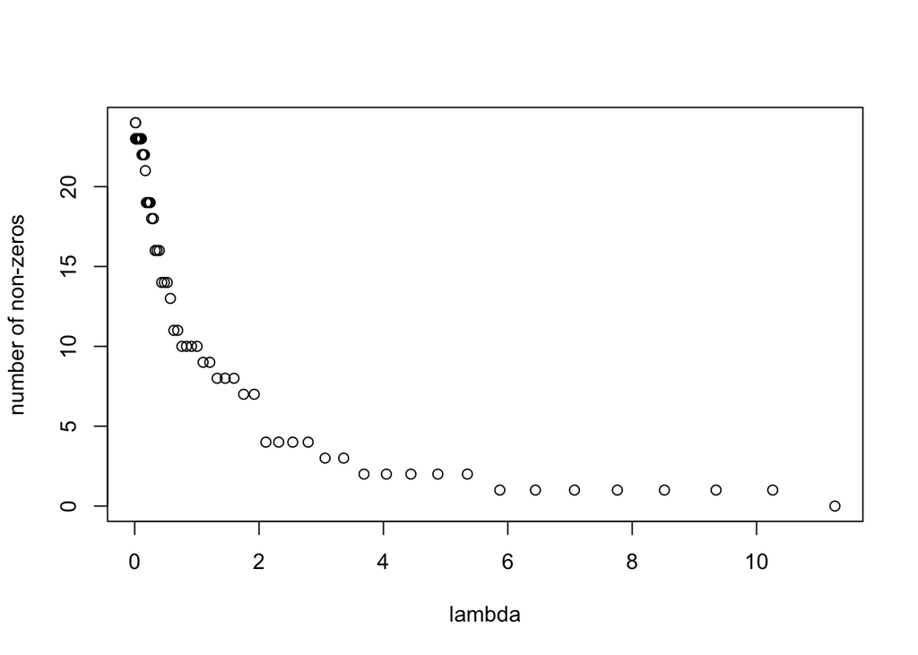

```r
plot(fit.cv$lambda, fit.cv$nzero, xlab="lambda", ylab="number of non-zeros") #as the value of lambda increases, the number of non-zero variables decreases
```

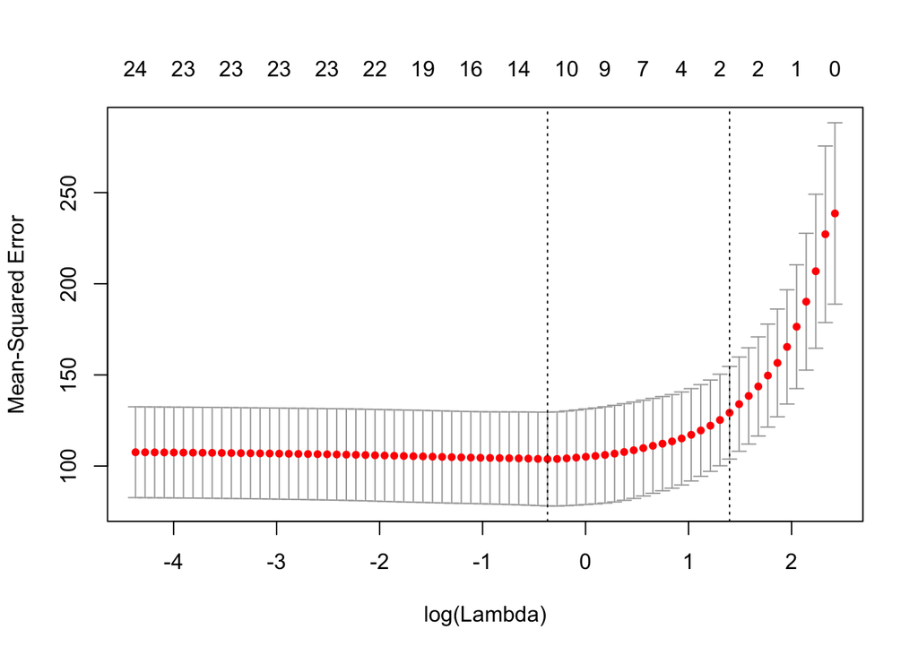

```r
plot(fit.cv) # this is suggesting we pick a value of lambda between the 2 dotted lines; The first vertical line is the lambda.min, or the λ which gives the smallest cvm. The second vertical line is lambda.1se, or largest λ whose cvm is within the cvsd bar for the lambda.min value.
```

Based on our cross-validation procedure, let’s proceed our LASSO with our minimum lambda value. This should retain 11 variables from our original dataset.

```r
coef.min <- coef(fit.cv, s="lambda.min")
coef.min <- coef.min[which(coef.min !=0),]   # get the non=zero coefficients
coef.min  # the set of predictors chosen
```

```
##                       (Intercept)            `Administrative tasks`
##                        3.88368953                        1.37365854
##             `Adoptions Assistant`              `Cat Care Volunteer`
##                       22.00082548                        1.02754665
## `Cat Pawsitive Program Volunteer`          `Cat Socialization Team`
##                        4.35472203                        0.24031232
##           `Dog Walking Volunteer`                      `Mutt Strut`
##                        2.93593550                        7.19293082
##                       other_event       `Veterinary Tech Volunteer`
##                        3.37806694                        7.74577160
##                         YTD.hours           t.orientation.to.shift1
##                        0.70183199                       -0.01565153
```

```r
var.min <- rownames(as.matrix(coef.min))
```

This shows us the 11 variables LASSO has selected as most contributing to the number of times an individual has volunteered.

We now enter these variables in a regression:

```r
(lm.input <- as.formula(paste("numTimeVolunteer", "~", paste(var.min[-1], collapse = "+")))) # prepare for lm fomula
```

```
## numTimeVolunteer ~ `Administrative tasks` + `Adoptions Assistant` +
##     `Cat Care Volunteer` + `Cat Pawsitive Program Volunteer` +
##     `Cat Socialization Team` + `Dog Walking Volunteer` + `Mutt Strut` +
##     other_event + `Veterinary Tech Volunteer` + YTD.hours + t.orientation.to.shift1
```

```r
fit.min.lm <- lm(lm.input, data=k_data_reg)
lm.output <- coef(fit.min.lm) # output lm estimates
summary(fit.min.lm)
```

```
##
## Call:
## lm(formula = lm.input, data = k_data_reg)
##
## Residuals:
##     Min      1Q  Median      3Q     Max
## -31.218  -4.201  -1.841   2.171  77.854
##
## Coefficients:
##                                    Estimate Std. Error t value Pr(>|t|)
## (Intercept)                        2.083890   1.083566   1.923  0.05526
## `Administrative tasks`             2.449461   2.722238   0.900  0.36884
## `Adoptions Assistant`             24.295610   5.291398   4.592 6.11e-06
## `Cat Care Volunteer`               2.966069   1.114105   2.662  0.00811
## `Cat Pawsitive Program Volunteer`  7.367933   3.298724   2.234  0.02613
## `Cat Socialization Team`           7.557707   5.544283   1.363  0.17370
## `Dog Walking Volunteer`            5.187843   1.306698   3.970 8.69e-05
## `Mutt Strut`                       8.143172   2.983986   2.729  0.00667
## other_event                        4.391984   1.503846   2.921  0.00372
## `Veterinary Tech Volunteer`       11.563707   4.499578   2.570  0.01058
## YTD.hours                          0.688023   0.056513  12.175  < 2e-16
## t.orientation.to.shift1           -0.023645   0.006676  -3.542  0.00045
##
## (Intercept)                       .
## `Administrative tasks`
## `Adoptions Assistant`             ***
## `Cat Care Volunteer`              **
## `Cat Pawsitive Program Volunteer` *
## `Cat Socialization Team`
## `Dog Walking Volunteer`           ***
## `Mutt Strut`                      **
## other_event                       **
## `Veterinary Tech Volunteer`       *
## YTD.hours                         ***
## t.orientation.to.shift1           ***
## ---
## Signif. codes:  0 '***' 0.001 '**' 0.01 '*' 0.05 '.' 0.1 ' ' 1
##
## Residual standard error: 9.267 on 356 degrees of freedom
## Multiple R-squared:  0.652,  Adjusted R-squared:  0.6413
## F-statistic: 60.64 on 11 and 356 DF,  p-value: < 2.2e-16
```

Here, we can see that as we originally investigated, t.orientation.to.shift1 is highly negatively associated with the number of times an individual volunteers.

It appears that volunteers who have assignments Adoptions Assistant, Cat Care Volunteer, Cat Pawsitive Program Volunteer, Dog Walking Volunteer, Mutt Strut, Veterinary Tech Volunteer, and other_event are more likely to have greater number of times volunteering.

Also, as we might expected, YTD.hours is highly positively associated with number of times volunteering.

Next steps: logistic regression to analyze numTimeVolunteer2 (e.g. repeat or once only volunteering?)